# hw8

2022-10-18

## Question 11.1

Using the crime data set uscrime.txt from Questions 8.2, 9.1, and 10.1, build a regression model using:

1. Stepwise regression
2. Lasso
3. Elastic net

#### 1. Stepwise regression

For the stepwise regression, I tried both forward selection and backward elimination methods. For each method, AIC test was done to check if the model was improved after the stepwise regression.

```r
# Load the data
data <- read.table("C:/Users/leajo/Documents/ISYE6501/HW8/hw8-SP22/data 11.1/uscrime.txt", header = TRUE)
```

**1) Forward selection**

Forward selection starts with a model with no factors. Therefore, the first thing I built is a model with only the interception.

```r
# Define the intercept-only model, starting with no variables
intercept_only <- lm(Crime~ 1, data = data)
intercept_only
```

```
##
## Call:
## lm(formula = Crime ~ 1, data = data)
##
## Coefficients:
## (Intercept)
##       905.1
```

AIC score for the interception-only model shows 696.40.

```r
AIC(intercept_only)
```

```
## [1] 696.4037
```

In order for comparison, a simple regression model with all variables were built and tested with AIC, with the value of 650.03. A simple regression with all variables could contain insignificant variables.

```r
# Define model with all predictors
all <- lm(Crime ~., data= data)
all
```

```
##
## Call:
## lm(formula = Crime ~ ., data = data)
##
## Coefficients:
## (Intercept)            M           So           Ed          Po1          Po2
##  -5.984e+03    8.783e+01   -3.803e+00    1.883e+02    1.928e+02   -1.094e+02
##          LF          M.F          Pop           NW           U1           U2
##  -6.638e+02    1.741e+01   -7.330e-01    4.204e+00   -5.827e+03    1.678e+02
##      Wealth         Ineq         Prob         Time
##   9.617e-02    7.067e+01   -4.855e+03   -3.479e+00
```

```r
AIC(all)
```

```
## [1] 650.0291
```

As a result of forward selection, six variables were selected: Po1, Ineq, Ed, M, Prob, and U2, where the residuals and coefficients are as follows:

```r
# Perform a forward selection stepwise regression
forward <- step(intercept_only, direction = 'forward', scope = formula(all), trace = 0)
forward$anova
```

```
##     Step Df  Deviance Resid. Df Resid. Dev      AIC
## 1        NA        NA        46    6880928 561.0235
## 2  + Po1 -1 3253301.8        45    3627626 532.9352
## 3 + Ineq -1  739818.6        44    2887807 524.2154
## 4   + Ed -1  587049.8        43    2300757 515.5343
## 5    + M -1  239404.6        42    2061353 512.3701
## 6 + Prob -1  258062.5        41    1803290 508.0839
## 7   + U2 -1  192233.4        40    1611057 504.7859
```

```r
forward$coefficients
```

```
## (Intercept)         Po1        Ineq          Ed           M        Prob
## -5040.50498   115.02419    67.65322   196.47120   105.01957 -3801.83628
##          U2
##    89.36604
```

Moreover, we could see that the AIC decreased compared to the all-variable model, which means the forward selection model has a better fit.

```r
AIC(forward)
```

```
## [1] 640.1661
```

**2) Backward elimination**

As for the next step, I built the backward elimination regression. The result shows that 8 variables remained (M, Ed, Po1, M.F, U1, U2, Ineq, Prob) and 7 variables were dropped (So, Time, LF, NW, Po2, Pop, Wealth).

```r
backward <- step(all, direction = "backward", scope = formula(all), trace =0)
backward
```

```
##
## Call:
## lm(formula = Crime ~ M + Ed + Po1 + M.F + U1 + U2 + Ineq + Prob,
##     data = data)
##
## Coefficients:
## (Intercept)            M           Ed          Po1          M.F           U1
##    -6426.10        93.32       180.12       102.65        22.34     -6086.63
##          U2         Ineq         Prob
##      187.35        61.33     -3796.03
```

These are the steps taken in the backward elimination:

```r
backward$anova
```

```
##       Step Df    Deviance Resid. Df Resid. Dev      AIC
## 1          NA          NA        31    1354946 514.6488
## 2     - So  1    28.57405        32    1354974 512.6498
## 3   - Time  1 10340.66984        33    1365315 511.0072
## 4     - LF  1 10533.15902        34    1375848 509.3684
## 5     - NW  1 11674.63991        35    1387523 507.7655
## 6    - Po2  1 16706.34095        36    1404229 506.3280
## 7    - Pop  1 22345.36638        37    1426575 505.0700
## 8 - Wealth  1 26493.24677        38    1453068 503.9349
```

The AIC result of the backward elimination shows a slightly better fit than the forward selection.

```r
AIC(backward)
```

```
## [1] 639.3151
```

I also quickly compared the R-squared and adjusted R-squared of the models of all variables, the forward selection and the backward elimination. As you can see, the R-squared is the highest when all variables were included. However, it does not directly mean that the model has predictive accuracy, because all the insignificant variables accompany noise to the model from the random patterns.

```r
summary(all)
```

```
##
## Call:
## lm(formula = Crime ~ ., data = data)
##
## Residuals:
##     Min      1Q  Median      3Q     Max
## -395.74  -98.09   -6.69  112.99  512.67
##
## Coefficients:
##               Estimate Std. Error t value Pr(>|t|)
## (Intercept) -5.984e+03  1.628e+03  -3.675 0.000893 ***
## M            8.783e+01  4.171e+01   2.106 0.043443 *
## So          -3.803e+00  1.488e+02  -0.026 0.979765
## Ed           1.883e+02  6.209e+01   3.033 0.004861 **
## Po1          1.928e+02  1.061e+02   1.817 0.078892 .
## Po2         -1.094e+02  1.175e+02  -0.931 0.358830
## LF          -6.638e+02  1.470e+03  -0.452 0.654654
## M.F          1.741e+01  2.035e+01   0.855 0.398995
## Pop         -7.330e-01  1.290e+00  -0.568 0.573845
## NW           4.204e+00  6.481e+00   0.649 0.521279
## U1          -5.827e+03  4.210e+03  -1.384 0.176238
## U2           1.678e+02  8.234e+01   2.038 0.050161 .
## Wealth       9.617e-02  1.037e-01   0.928 0.360754
## Ineq         7.067e+01  2.272e+01   3.111 0.003983 **
## Prob        -4.855e+03  2.272e+03  -2.137 0.040627 *
## Time        -3.479e+00  7.165e+00  -0.486 0.630708
## ---
## Signif. codes:  0 '***' 0.001 '**' 0.01 '*' 0.05 '.' 0.1 ' ' 1
##
## Residual standard error: 209.1 on 31 degrees of freedom
## Multiple R-squared:  0.8031, Adjusted R-squared:  0.7078
## F-statistic: 8.429 on 15 and 31 DF,  p-value: 3.539e-07
```

```r
summary(forward)
```

```
##
## Call:
## lm(formula = Crime ~ Po1 + Ineq + Ed + M + Prob + U2, data = data)
##
## Residuals:
##     Min      1Q  Median      3Q     Max
## -470.68  -78.41  -19.68  133.12  556.23
##
## Coefficients:
##             Estimate Std. Error t value Pr(>|t|)
## (Intercept) -5040.50     899.84  -5.602 1.72e-06 ***
## Po1           115.02      13.75   8.363 2.56e-10 ***
## Ineq           67.65      13.94   4.855 1.88e-05 ***
## Ed            196.47      44.75   4.390 8.07e-05 ***
## M             105.02      33.30   3.154  0.00305 **
## Prob        -3801.84    1528.10  -2.488  0.01711 *
## U2             89.37      40.91   2.185  0.03483 *
## ---
## Signif. codes:  0 '***' 0.001 '**' 0.01 '*' 0.05 '.' 0.1 ' ' 1
##
## Residual standard error: 200.7 on 40 degrees of freedom
## Multiple R-squared:  0.7659, Adjusted R-squared:  0.7307
## F-statistic: 21.81 on 6 and 40 DF,  p-value: 3.418e-11
```

```r
summary(backward)
```

```
##
## Call:
## lm(formula = Crime ~ M + Ed + Po1 + M.F + U1 + U2 + Ineq + Prob,
##     data = data)
##
## Residuals:
##     Min      1Q  Median      3Q     Max
## -444.70 -111.07    3.03  122.15  483.30
##
## Coefficients:
##             Estimate Std. Error t value Pr(>|t|)
## (Intercept) -6426.10    1194.61  -5.379 4.04e-06 ***
## M              93.32      33.50   2.786  0.00828 **
## Ed            180.12      52.75   3.414  0.00153 **
## Po1           102.65      15.52   6.613 8.26e-08 ***
## M.F            22.34      13.60   1.642  0.10874
## U1          -6086.63    3339.27  -1.823  0.07622 .
## U2            187.35      72.48   2.585  0.01371 *
## Ineq           61.33      13.96   4.394 8.63e-05 ***
## Prob        -3796.03    1490.65  -2.547  0.01505 *
## ---
## Signif. codes:  0 '***' 0.001 '**' 0.01 '*' 0.05 '.' 0.1 ' ' 1
##
## Residual standard error: 195.5 on 38 degrees of freedom
## Multiple R-squared:  0.7888, Adjusted R-squared:  0.7444
## F-statistic: 17.74 on 8 and 38 DF,  p-value: 1.159e-10
```

#### 2. Lasso regression

For Lasso regression, I first prepared the data by scaling them and splitting into training and test set. Then, I ran a Lasso regression using `glmnet()`, tried to find the best lambda value by `cv.glmnet()` and checked the RMSE of the Lasso regression.

```r
# Scale the data set for Lasso regression
data_scaled <- scale(data, center = TRUE, scale = TRUE)
data_scaled <- as.data.frame(data_scaled)
head(data_scaled)
```

```
##            M         So         Ed        Po1        Po2         LF         M.F
## 1  0.9886930  1.3770536 -1.3085099 -0.9085105 -0.8666988 -1.2667456 -1.12060499
## 2  0.3521372 -0.7107373  0.6580587  0.6056737  0.5280852  0.5396568  0.98341752
## 3  0.2725678  1.3770536 -1.4872888 -1.3459415 -1.2958632 -0.6976051 -0.47582390
## 4 -0.2048491 -0.7107373  1.3731746  2.1535064  2.1732150  0.3911854  0.37257228
## 5  0.1929983 -0.7107373  1.3731746  0.8075649  0.7426673  0.7376187  0.06714965
## 6 -1.3983912 -0.7107373  0.3898903  1.1104017  1.2433590 -0.3511718 -0.64550313
##           Pop           NW          U1         U2     Wealth       Ineq
## 1 -0.09500679  1.943738564  0.69510600  0.8313680 -1.3616094  1.6793638
## 2 -0.62033844  0.008483424  0.02950365  0.2393332  0.3276683  0.0000000
## 3 -0.48900552  1.146296747 -0.08143007 -0.1158877 -2.1492481  1.4036474
## 4  3.16204944 -0.205464381  0.36230482  0.5945541  1.5298536 -0.6767585
## 5 -0.48900552 -0.691709391 -0.24783066 -1.6551781  0.5453053 -0.5013026
## 6 -0.30513945 -0.555560788 -0.63609870 -0.5895155  1.6956723 -1.7044289
##         Prob        Time      Crime
## 1  1.6497631 -0.05599367 -0.2949744
## 2 -0.7693365 -0.18315796  1.8872422
## 3  1.5969416 -0.32416470 -0.8456997
## 4 -1.3761895  0.46611085  2.7508209
## 5 -0.2503580 -0.74759413  0.8504308
## 6 -0.5669349 -0.78996812 -0.5768010
```

```r
# Set seed for generating random number
set.seed(133)

# Split the data set into training and test set
index <- sample(c(TRUE, FALSE), nrow(data_scaled), replace = TRUE, prob = c(0.7,0.3))

data_scaled_train <- data_scaled[index, ]
data_scaled_test<- data_scaled[-index, ]

train_x <- as.matrix(data_scaled_train[,1:15])
train_y <- data_scaled_train$Crime

test_x <- as.matrix(data_scaled_test[,1:15])
test_y <- data_scaled_test$Crime
```

I ran the Lasso regression on the training data set, and plotted the model coefficients for a range of regularization parameter, lambda (log lambda). The plot shows how Lasso regression works: by increasing the value of lambda, the coefficients become closer to 0 as a process of variable selection.

```r
library(glmnet)
```

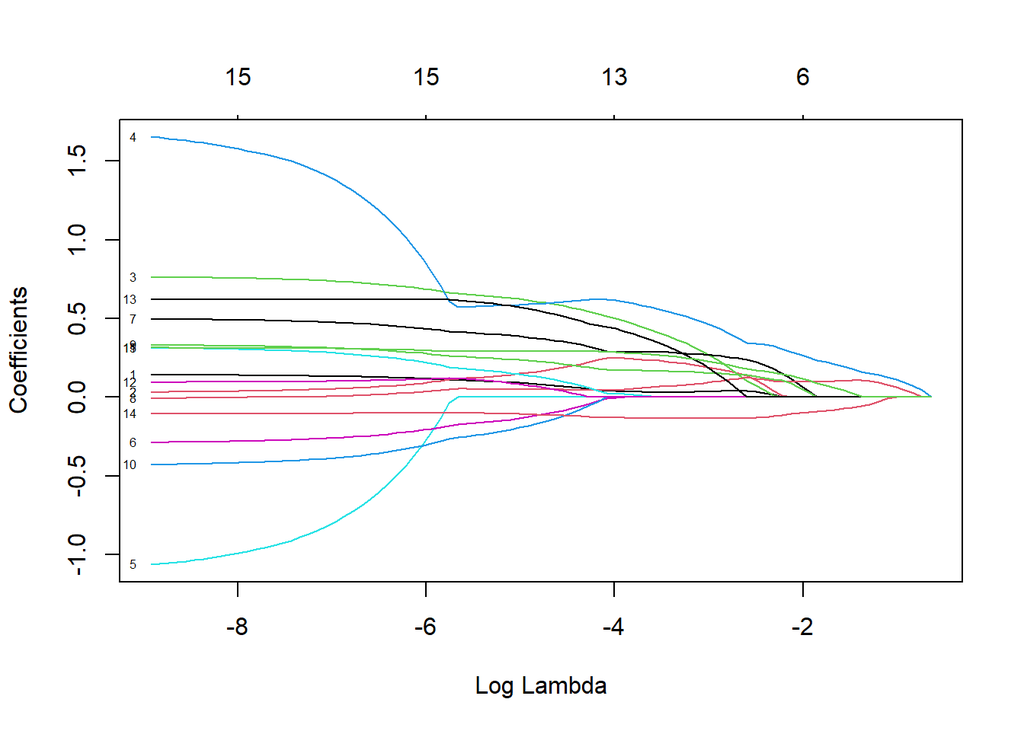

```r
m.lasso <- glmnet(train_x, train_y, alpha = 1)
plot(m.lasso, xvar = "lambda", label = TRUE)
```

In the next step, I tried to find the best lambda, which minimizes the residuals between the actual values and the predicted values by using k-fold cross-validation with `cv.glmnet()`. The result shows that when the residuals are minimized, the lambda is 0.02685191.

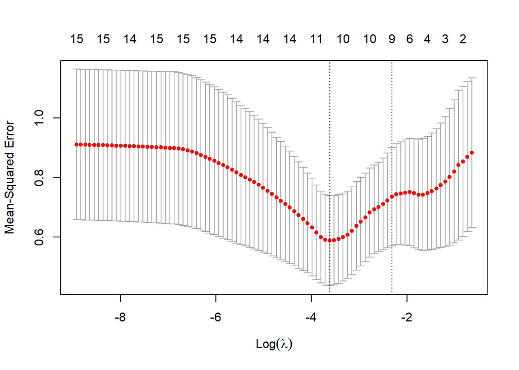

```r
m.lasso.cv <- cv.glmnet(train_x, train_y, alpha = 1)
plot(m.lasso.cv)
```

```r
m.lasso.cv$lambda.min
```

```
## [1] 0.02685191
```

And these are the coefficients of the selected variables by the Lasso regression:

```r
cf <- as.matrix(coef(m.lasso.cv,m.lasso.cv$lambda.min))
cf[cf!= 0,]
```

```
##  (Intercept)            M           So           Ed          Po1          M.F
##  0.019400726  0.031109561  0.236099110  0.429237368  0.572611277  0.288374004
##          Pop           NW           U2         Ineq         Prob         Time
##  0.062085724  0.168007099  0.004534587  0.365272871 -0.131853366  0.272693723
```

And this is the RMSE of the chosen Lasso regression:

```r
m.lasso.cv.pred.train <- predict(m.lasso.cv, train_x, s = "lambda.min")
sqrt(mean((train_y - m.lasso.cv.pred.train)^2)) # rmse
```

```
## [1] 0.4189946
```

Then, the test dataset was put in the Lasso regression model for prediction and RMSE was calculated. RSME of the test set is higher than that of the training set, which is normal.

```r
m.lasso.cv.pred.train <- predict(m.lasso.cv, test_x, s = "lambda.min")
sqrt(mean((test_y - m.lasso.cv.pred.train)^2)) # rmse
```

```
## [1] 0.5725884
```

Finally, Lasso Regression was performed with the original data set, with the RMSE value of 0.567.

```r
# Seperate the predictor and response variables
x <- as.matrix(data_scaled[,1:15])
y <- data_scaled$Crime

# Run the Lasso regression

pred <- predict(m.lasso.cv, x, s = "lambda.min")
sqrt(mean((y -pred)^2)) #RMSE
```

```
## [1] 0.5664809
```

If we compare the result with RMSE of all variables, we can see that the RMSE is bigger in the Lasso regression. As a result of regularized regression, we traded bias for low variance to prevent overfitting.

```r
all_scaled <- lm(Crime ~., data= data_scaled)
sqrt(mean((y - all_scaled$fitted.values)^2)) #RMSE
```

```
## [1] 0.439003
```

#### 3. Elastic net

Elastic net regression is a mixture of Lasso and Ridge regression, where the alpha value for `glmnet()` lies between 0 and 1.

Here, I tried to find the best alpha and lambda value using 5-fold cross-validation without splitting the data set, and compared the coefficients and RMSE of the Elastic net regression with the simple regression with all variables.

For the first step, I trained the Elastic net regression model by 5-fold cross-validation. Three alpha and three lambda values were tested and RMSE was the smallest when the alpha is 0.1 and the lambda is 0.13605.

```r
library("caret")
set.seed(33)
cv_5 <- trainControl(method = "cv", number = 5)

cv.elnet <- train(
  Crime ~., data = data_scaled,
  method = "glmnet", trControl = cv_5,
)
cv.elnet
```

```
## glmnet
##
## 47 samples
## 15 predictors
##
## No pre-processing
## Resampling: Cross-Validated (5 fold)
## Summary of sample sizes: 36, 38, 38, 38, 38
## Resampling results across tuning parameters:
##
##   alpha  lambda     RMSE       Rsquared   MAE
##   0.10   0.0013605  0.8092144  0.4737470  0.6301021
##   0.10   0.0136050  0.7622960  0.5122074  0.6001728
##   0.10   0.1360500  0.7428038  0.5108110  0.5954416
##   0.55   0.0013605  0.8140427  0.4706159  0.6339561
##   0.55   0.0136050  0.7600713  0.5198577  0.6011708
##   0.55   0.1360500  0.7742470  0.4711759  0.6208238
##   1.00   0.0013605  0.8199275  0.4675542  0.6387179
##   1.00   0.0136050  0.7580412  0.5249963  0.5985898
##   1.00   0.1360500  0.8020325  0.4948924  0.6528669
##
## RMSE was used to select the optimal model using the smallest value.
## The final values used for the model were alpha = 0.1 and lambda = 0.13605.
```

```r
# Saving the best alpha and lambda as a variable
best_elnet <- cv.elnet$bestTune
best_elnet
```

```
##   alpha  lambda
## 3   0.1 0.13605
```

If we expand the tuning length to 10, it tests 10 alpha and lambda values and returns each result. The smallest RMSE was when alpha is 1.0, basically like a Lasso regression. However, as the purpose of this exercise is to try Elastic net, I will go with the best result from the initial Elastic net regression, alpha 0.1 and lambda 0.13605.

```r
cv.elnet2 <- train(
  Crime ~., data = data_scaled,
  method = "glmnet", trControl = cv_5,
  tuneLength = 10
)
cv.elnet2
```

```
## glmnet
##
## 47 samples
## 15 predictors
##
## No pre-processing
## Resampling: Cross-Validated (5 fold)
## Summary of sample sizes: 38, 37, 38, 38, 37
## Resampling results across tuning parameters:
##
##   alpha  lambda        RMSE       Rsquared   MAE
##   0.1    0.0003142932  0.7560954  0.5048447  0.6059187
##   0.1    0.0007260581  0.7558499  0.5049416  0.6057287
##   0.1    0.0016772884  0.7530826  0.5055681  0.6059149
##   0.1    0.0038747539  0.7475873  0.5071394  0.6051352
##   0.1    0.0089511840  0.7360997  0.5118080  0.5971789
##   0.1    0.0206783959  0.7152402  0.5218328  0.5838073
##   0.1    0.0477697766  0.6904947  0.5305374  0.5744438
##   0.1    0.1103543797  0.6691540  0.5315960  0.5701602
##   0.1    0.2549329301  0.6768753  0.5021454  0.5760451
##   0.1    0.5889281332  0.7349933  0.4613096  0.6120911
##   0.2    0.0003142932  0.7568579  0.5043743  0.6053385
##   0.2    0.0007260581  0.7552719  0.5054863  0.6051550
##   0.2    0.0016772884  0.7520197  0.5064632  0.6051859
##   0.2    0.0038747539  0.7455096  0.5088118  0.6036975
##   0.2    0.0089511840  0.7316843  0.5154545  0.5927065
##   0.2    0.0206783959  0.7071830  0.5288348  0.5765112
##   0.2    0.0477697766  0.6853025  0.5305896  0.5737994
##   0.2    0.1103543797  0.6695934  0.5214319  0.5715548
##   0.2    0.2549329301  0.6943983  0.4763778  0.5878782
##   0.2    0.5889281332  0.7603875  0.4696218  0.6202925
##   0.3    0.0003142932  0.7565126  0.5046878  0.6048482
##   0.3    0.0007260581  0.7547832  0.5059380  0.6047497
##   0.3    0.0016772884  0.7509883  0.5073308  0.6044808
##   0.3    0.0038747539  0.7434994  0.5104504  0.6023124
##   0.3    0.0089511840  0.7271701  0.5193673  0.5882745
##   0.3    0.0206783959  0.7008535  0.5348476  0.5702177
##   0.3    0.0477697766  0.6824315  0.5297006  0.5729177
##   0.3    0.1103543797  0.6771081  0.4996710  0.5756598
##   0.3    0.2549329301  0.7101277  0.4723134  0.5966662
```

[output cut: 59 more lines]

```
##   0.9    0.2549329301  0.7563623  0.4867148  0.6134167
##   0.9    0.5889281332  0.8947288  0.5008258  0.6863330
##   1.0    0.0003142932  0.7546318  0.5058030  0.6033621
##   1.0    0.0007260581  0.7523173  0.5079952  0.6027848
##   1.0    0.0016772884  0.7443186  0.5130486  0.6002932
##   1.0    0.0038747539  0.7269037  0.5255207  0.5880575
##   1.0    0.0089511840  0.6948913  0.5491578  0.5604671
##   1.0    0.0206783959  0.6738059  0.5486543  0.5536097
##   1.0    0.0477697766  0.6613998  0.5249065  0.5590365
##   1.0    0.1103543797  0.6947561  0.4990564  0.5853886
##   1.0    0.2549329301  0.7575480  0.4980674  0.6091489
##   1.0    0.5889281332  0.9274660  0.5010876  0.7142868
##
## RMSE was used to select the optimal model using the smallest value.
## The final values used for the model were alpha = 1 and lambda = 0.04776978.
```

So, in the next step, I performed Elastic net regression with the best values of alpha and lambda from the cross-validation.

```r
m.elnet <- glmnet(x, y, lambda = best_elnet$lambda, alpha = best_elnet$alpha)
```

As a result of the regularization, we can see that the coefficients significantly decreased compared to the simple regression with all variables. Among the variables, “Pop” was dropped.

Because we are not able to completely identify random patterns from the real patterns, we are reducing the overall fit to prevent overfitting. By doing this, we can add bias but help reducing variances.

```r
# Coefficients for elastic net
elnet_eff_mtr <- coef(m.elnet)
elnet_eff_df <- as.data.frame(as.matrix(elnet_eff_mtr))

# Coefficients for simple regression
all_coeff<- as.data.frame(all_scaled$coefficients)


coeff_merge <- merge(elnet_eff_df, all_coeff, by = 'row.names')
colnames(coeff_merge) <- c("Predictors","Elastic net", "Simple regression")

coeff_merge
```

```
##     Predictors   Elastic net Simple regression
## 1  (Intercept) -3.656116e-16     -1.323896e-16
## 2           Ed  2.186248e-01      5.447226e-01
## 3         Ineq  3.050425e-01      7.290099e-01
## 4           LF  5.423891e-02     -6.936144e-02
## 5            M  1.804771e-01      2.853992e-01
## 6          M.F  1.631405e-01      1.326225e-01
## 7           NW  7.951237e-02      1.117842e-01
## 8          Po1  3.827510e-01      1.481515e+00
## 9          Po2  2.849612e-01     -7.910746e-01
## 10         Pop  0.000000e+00     -7.215404e-02
## 11        Prob -2.138841e-01     -2.854309e-01
## 12          So  9.717769e-02     -4.710274e-03
## 13        Time  5.973951e-03     -6.374822e-02
## 14          U1 -8.085619e-02     -2.716280e-01
## 15          U2  1.645700e-01      3.664117e-01
## 16      Wealth  5.566268e-02      2.399190e-01
```

We confirm here that the RMSE of the Elastic net regression is larger than the RMSE of the simple regression of all variables, 0.439003. It means that there was a trade-off, as we added more bias by reducing variables and variances.

```r
# Model prediction of Elastic net and RSME

pred.elnet <- predict(m.elnet, x)
sqrt(mean((y - pred.elnet )^2))
```

```
## [1] 0.5053691
```